# R Basics Part 1

17 September 2025

# 1 Objectives

- Be able to do arithmetic in R
- Be able to create the common R objects
- Understand the type of objects
- Import and export data
- Data manipulation with {dplyr}
- *Data visualization with {ggplot2}

# 2 Questions

- What will these lessons not cover?

# 3 Introduction

## 3.1 Prepare the tutorial folder

- Open the terminal. Execute the following commands one by one.
  - *$ cd ~/Document*
  - *$ git clone https://github.com/bulahwoo/r_tutorial_part1.git*
  - *$ cd ./r_tutorial_part1*
  - *$ pwd*
- Check the content of the current directory by
  - *$ ls -lh ./*

## 3.2 Install R

- Are you in the `r_tutorial_part1` directory (folder)? Check by:
  - *$ pwd*
- Is R already installed? You can check by:
  - *$ R*
- If you see something like this, R is installed. Skip the next step.

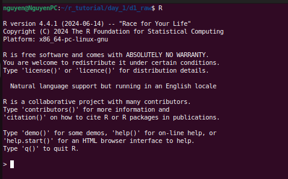

- If you see something like this, R is not installed. Execute the bash script:
  - *$ bash ./install/r_install.sh*

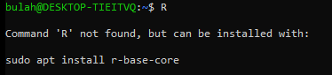

## 3.3 R console

- By typing “R” at a prompt, you will open the R console.
  - *$ R*

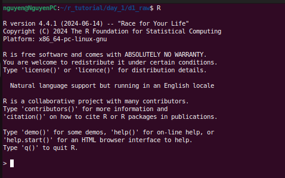

- How to quit R console? Type `q()` and `Enter` to quit R.
- A blinking “caret” appear next to the “greater than” sign `>`, referred to as a **prompt**. This is where you’ll type R commands.
- Type `3 + 12` at the prompt, and press “enter” to execute the command.

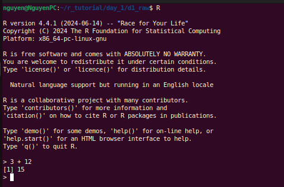

- Try these arithmetic operators:

| Operator | Name |
| --- | --- |
| + | Addition |
| - | Subtraction |
| * | Multiplication |
| / | Division |
| ^ | Exponent |
| %% | Modulus (Remainder from division) |

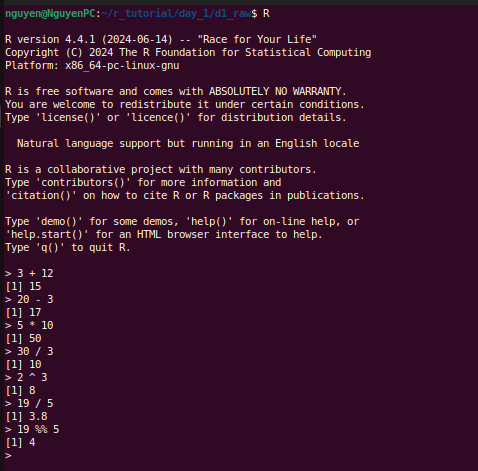

- Try to use `Up` and `Down` keys to view the previous command lines.

## 3.4 Install RStudio

- RStudio is an integrated development environment (IDE) for R.
- IDE is a software application that helps programmers develop software code efficiently.
  - Syntax highlighting
  - Intelligent code completion
  - Code editing automation
  - and more…
- Are you in the `r_tutorial_part1` directory (folder)? Check by:
  - *$ pwd*
- Is RStudio already installed? You can check by:
  - *$ rstudio --no-sandbox*
- If you see something like this, RStudio is installed. Skip the next step.

[figure not shown]

- If you don’t see RStudio window, RStudio is not installed. Execute the bash script:
  - *$ bash ./install/for_rstudio_install.sh*

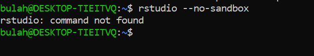

## 3.5 RStudio interface

- Open the terminal and move to the directory `r_tutorial_part1`.
  - *$ cd ~/Document/r_tutorial_part1*
- Launch RStudio by:
  - *$ rstudio --no-sandbox*

[figure not shown]

- Go to the file menu (upper-left corner) and click `File` –> `New File` –> `R Script`.

[figure not shown]

- Move the mouse cursor to the console panel (bottom-left), and repeat what we did previously in the R console.

```r
3 + 12
20 - 3
5 * 10
30 / 3
2 ^ 3
19 / 5
19 %% 5
```

- Write your code in the source panel and save it
  - Copy the command lines above, and paste the command lines above to the source panel.
  - Go to the file menu (upper-left corner) and click `File` –> `Save`. *It is recommended to avoid using spaces when naming files and folders. Instead, substituting them with underscores, for example, “my_script”.*
  - In the source panel, move the mouse cursor to line 3.
  - Press `Ctrl + Enter` keys (Press the `Ctrl` key, hold it, then press the `Enter` key, and finally release both keys at the same time.)
  - You can see, in the console panel, the command (line 3) was executed and the result is displayed.
  - Try to execute the rest of the code by using `Ctrl + Enter` keys in the source panel.

## 3.6 Assignment operator `<-`

- NAME `<-` OBJECT
- Create an object OBJECT, and name it NAME.
- *Spaces are NOT OK inside NAME.*
  - Don’t do this:

  ```r
  my car <- 5
  ```

  ```
  ## Error in parse(text = input): <text>:1:4: unexpected symbol
  ## 1: my car
  ##        ^
  ```

- Logical, Integer, Double, and Character type
  - Integer (such as **1**, **53**, **221**) and double (such as **0.3**, **1.89**, **41.333**) are known as numeric type

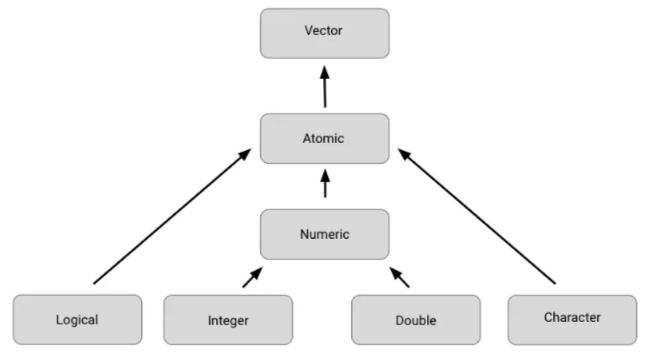

- Let’s create an object 13.6, and give it a name **jojo**.

```r
jojo <- 13.6
```

- We can print the object by typing the name of it and hitting `Enter`.

```r
jojo
```

```
## [1] 13.6
```

- Create a character object VINO, and give this object a name **kiki**.

```r
kiki <- "VINO"
kiki
```

```
## [1] "VINO"
```

- Let’s create two objects and name them **money** and **note**.

```r
money <- 1000
note <- "1000"
```

```r
money
```

```
## [1] 1000
```

```r
note
```

```
## [1] "1000"
```

```r
typeof(money)
```

```
## [1] "double"
```

```r
typeof(note)
```

```
## [1] "character"
```

- What would happen if you do basic arithmetic operations on a character object?

```r
money + note
```

```
## Error in money + note: non-numeric argument to binary operator
```

- Now you know how to create a character object and a numeric object. Let’s see what a **logical** object is.

```r
12 == 12
```

```
## [1] TRUE
```

```r
12 == 20
```

```
## [1] FALSE
```

In R, `TRUE` and `FALSE` are reserved words denoting logical constants.

```r
duck <- 12 == 12
goose <- FALSE
```

```r
duck
```

```
## [1] TRUE
```

```r
goose
```

```
## [1] FALSE
```

## 3.7 Vector

- A one-dimensional data structure that holds elements **of the same data type**.
- Create a vector with the c() function.

```r
investment <- c("CZK", "EUR", "USD")
earning <- c(300, 50, 2)
cash <- c(T, F, F) # identical to cash <- c(TRUE, FALSE, FALSE)
```

```r
investment
```

```
## [1] "CZK" "EUR" "USD"
```

```r
earning
```

```
## [1] 300  50   2
```

```r
cash
```

```
## [1]  TRUE FALSE FALSE
```

- You can access a single element in a vector by its position, aka **index**.
- In R, indexes start at 1 – the 1st element is at index 1.
- Indexes are **numeric**.
- VECTOR[INDEX]

```r
investment[1]
```

```
## [1] "CZK"
```

```r
earning[2]
```

```
## [1] 50
```

```r
cash[3]
```

```
## [1] FALSE
```

- You can access a set of specific elements by their indexes.
- Remember, indexes are numeric. Use the function c() to create a numeric vector that holds the indexes.

```r
investment
```

```
## [1] "CZK" "EUR" "USD"
```

```r
investment[c(1,2)]
```

```
## [1] "CZK" "EUR"
```

```r
investment[c(3,1,2)]
```

```
## [1] "USD" "CZK" "EUR"
```